# R Notebook

# Introduction

From Eric’s email:

> What the figure aims to show is that the effect of EBV infection is lost with the dRdZ mutant which looks more like an uninfected NOK with respect to the change in the signature genes upon MC treatment.

We prepare the data, basically load and remove genes with very low counts,

Since we want to obtain the genes that are differentially expressed (upregulated / downregulated) due to the treatment’s effect, we need to prepare two models, one coded in terms of the full model and another in terms of the interactions.

1. Get differentially expressed genes for all genes, and by cell
2. Compare EBV and NOKS differentially expressed genes vs all by `methyl` treat
- Upregulated genes

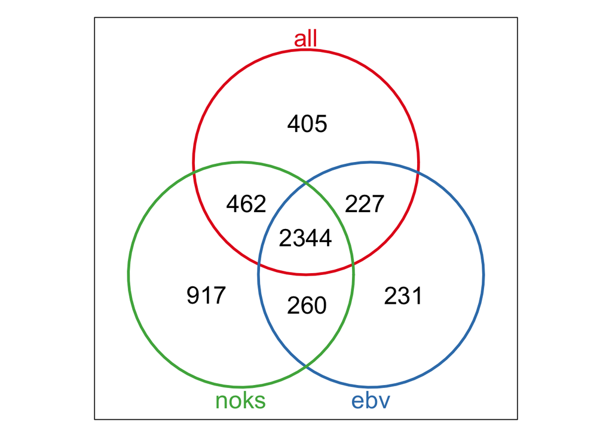

- Downregulated genes

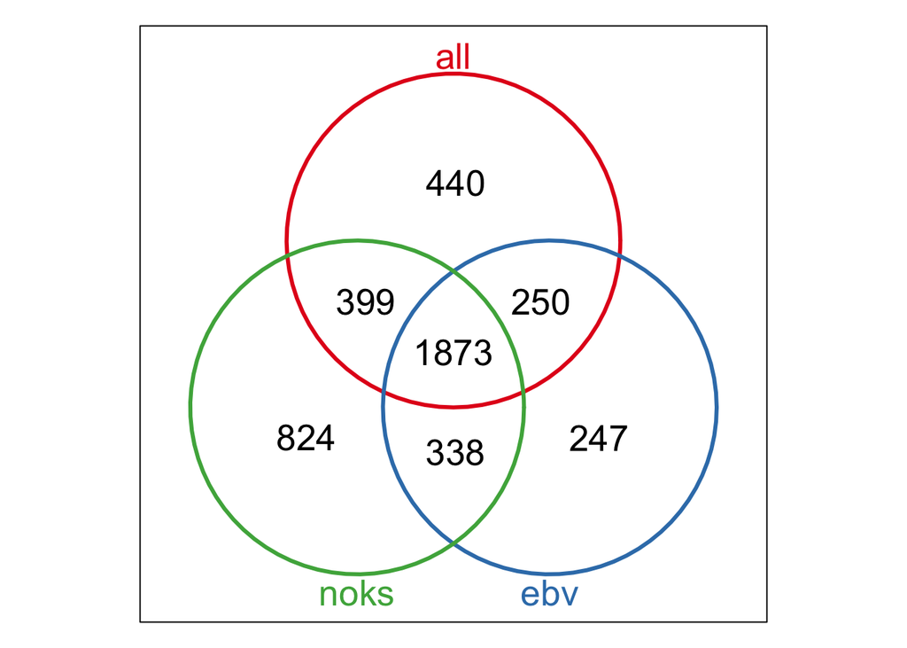

3. Compare the genes that are differentially expressed by treatment for ebv or noks but not all.

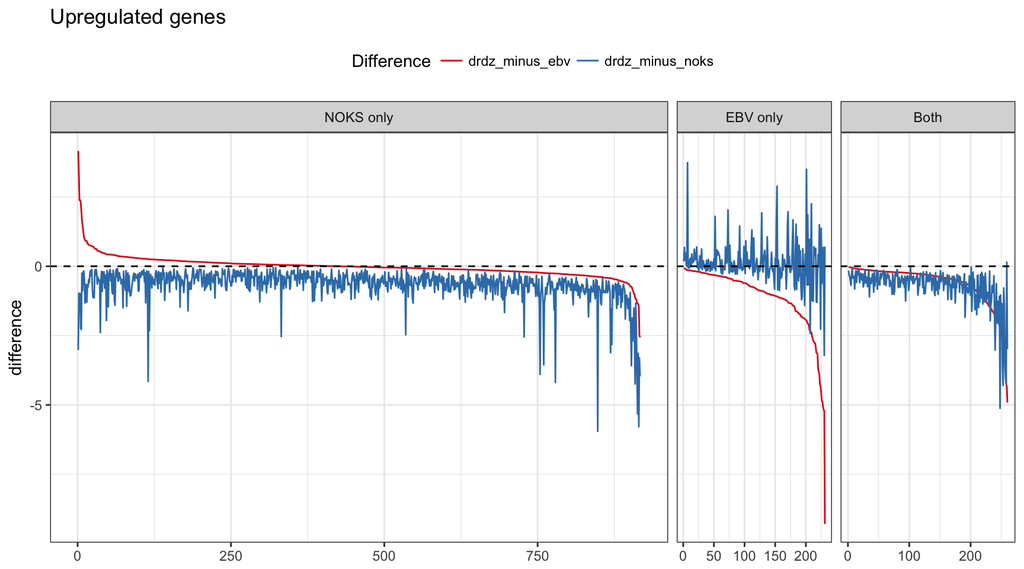

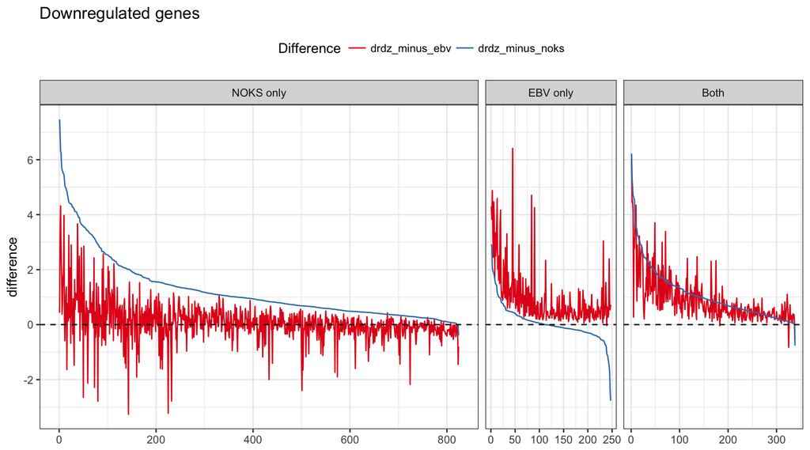